# Otkrivanje znanja u podacima - Završni projekt

Autori:

Anton Ilić,

Lorena Mršić

Mentor:

prof.dr.sc.* Maja Matetić

Kolegij:

Otkrivanje znanja u podacima

Odjel za informatiku Sveučilišta u Rijeci

Siječanj, 2021

# 1 Radni zadatak

Projektni zadatak je sastavni dio kolegija Otkrivanje znanja u podacima. Cilj je uz pomoć programske podrške u programskom jeziku R riješiti nebalansirani problem na praktičnom primjeru. Cilj je izgraditi model koji predviđa zrelost voća pomoću parametara izbjegavajući invazivne metode kao što je su naprimjer stiskanje voća radi provjere tvrdoće ili provođenje struje.

Zadatak uključuje inicijalnu pripremu podataka te balansiranje SMOTE (*Eng. Synthetic Minority Oversampling TEchnique*) algoritmom. Nad obrađenim podacima je potrebno izvršiti predviđanje zrelosti algoritmima Random forest i logističkom regresijom te dodatno objašnjenje važnosti varijabli paketom DALEX korištenjem permutacija.

# 2 Opis skupa podataka

Neka od svojstva koja su opisana se odnose na veličinu, masu, čvrstoću, provodljivost struje te razne aspekte boja i nijansi. Podaci su pretežito u decimalnom tipu, uz iznimku subjektivne procjene postotka ploda prekrivenosti bojom. Ta je vrijednost određena pomoću ljudskog faktora, a ocjenjena je slovima A do F.

Radi se o nebalansiranom skupu podataka, što znači da je u njemu otežana podjela podataka u skupove. Pritom pri podjeli u skupove problem predstavlja mala količina voća klasificiranog kao zrelo. U tu svrhu se uvodi metoda za stvaranje sintetičkih vrijednosti u svrhu stvaranja ravnoteže između broja zrelog i nezrelog voća.

# 3 Korišteni algoritmi

## 3.1 SMOTE

SMOTE (*Eng. Synthetic Minority Oversampling TEchnique*) je algoritam koji se koristi kod modela strojnog učenja u kojima jedna klasa prevladava nad drugom.

Algoritam sadrži nekoliko parametara koji definiraju rješenje ovisno o prirodi problema, a ta rješenja su:

- Sinteza vrijednosti slabije zastupljene klase
- Preuzrokovanje slabije zastupljene klase
- Poduzrokovanje jače zastuppljene klase
- Pridodavanje većeg prioriteta slabije zastupljenoj klasi u odnosu na jače zastupljenu klasu.

Slabije zastupljenoj klasi se pritom dodaju sintetizirane vrijednosti iz intervala postojećih vrijednosti. Pritom se koristi algoritam k-Najbližih susjeda (kNN).

Podešavanje algoritma se sastoji od odabira ciljne varijable nad skupom podataka, broja najbližih susjeda i željenog broja slučajeva pridodanih od strane jače i slabije zastupljene varijable.

## 3.2 Random Forest

Random Forest algoritam je metoda nadziranog učenja koja je poznata po svojoj preciznosti. Koristi se kod zadataka klasifikacije i regresije, a čine ga stabla odluke.

Algoritam gradi stabla odluke ovisno o predefiniranom broju stabala i uzoraka s određenim ponavljanjem. Grananjem se priotm određuje atribut te izgrađuje grana koja će za taj atribut pružati najveću informacijsku dobit.

Neke od mogućnosti koje algoritam pruža su odabir prediktora za što bolju korelaciju, broj varijabli u svakom čvoru, broj stabala, metoda razdvajanja stabala, *itd*…

Radi se o jako korisnom algoritmu, ali veliki problem predstavlja brzina izvođenja nad većim skupovima podataka, što u ovom slučaju neće biti problem.

## 3.3 Logistička regresija

Logistička regresija je klasifikacijski algoritam nadziranog učenja koji se koristi za pridruživanje opservacija diskretnom skupu klasa. Rezultat logističke regresije je sigmoidna funkcija koja označava vjerojatnost koja se može pridodavati korištenim klasama.

Radi se o binarnoj klasifikaciji čiji je krajnji rezultat vrijednost istinita ili lažna, a rezultati mogu poslužiti za određivanja uzročnosti na dobiveni model. Drugim riječima, logističkom regresijom je moguće odrediti utjecaj varijabli na i njihovih vrijednosti na konačni ishod.

Neki od ulaznih parametara koje logistička regresija prima su skup podataka, odgovarajuća ciljna varijabla i metoda opisa greške.

## 3.4 Metrika važnosti varijable paketa DALEX

Metrika važnosti varijable implementirana paketom DALEX fokusira se na mjerenje razlike u performansi modela isključivanjem ili modificiranjem jedne ili više varijabli. Pritom vrijednosti u ovoj metodi na neki način nisu isključene, već bivaju promjenjene kombinatornim postupkom permutiranja.

Permutaciju definiramo kao svaku uređenu *n*-torku skupa od *n* elemenata. Broj permutacija *n*-članog skupa je:

**Pn = *n*·(*n*-1)·…·2·1**

Drugim riječima, radi se o nizu brojeva u kojem je poredak striktno određen te se koristi druga vrijednost niza pri svakom pokušaju. Radi veće efikasnosti postupak se ponavlja u više iteracija, odnosno permutacija.

Osnovna pretpostavka u procjeni metrike predlaže da ukoliko je varijabla važna, njezinim permutiranjem će se vrijednosti u modelu značajno promijeniti. Pritom se metrika određuje promjenom u performansu, odnosno što je varijabla važnija, to će se model više pogoršati.

# 4 Priprema podataka

Za provođenje analize u ovom tipu, podatke je potrebno refaktorirati u određene oblike koji su kompatibilni s algoritmima koji će se koristiti.

## 4.1 Učitavanje skupa podataka

Skup podataka je u originalu uručen u obliku *.xls* tablice koju je ručno potrebno prevesti u *.csv*. Pritom je za obradu i čitanje u većem djelu obrade podataka korišten paket *Tidyverse*. Radi čitanja *.csv* datoteke u Europskom formatu, korišten je *read_csv2* uz eksplicitnu naznaku encoding svojstva.

Budući da algoritmi koji se koriste u svrhu ovog projekta ne toleriraju tekstualne vrijednsti tipa *char*, stupac *AE* je preveden u numerički oblik.

```r
# Data was originaly given in .xls file.

# Reading data from .csv file
data = read_csv2('peaches_100_ALL_2.csv', locale = locale(encoding = 'UTF-8'))

# Changing character type column to int for further processing
data$AE[data$AE == 'A'] = 6    #90-100% (A) - 6
data$AE[data$AE == 'B'] = 5    #80-90% (B) - 5
data$AE[data$AE == 'C'] = 4    #70-80% (C) - 4
data$AE[data$AE == 'D'] = 3    #50-70% (D) - 3
data$AE[data$AE == 'E'] = 2    #25-50% (E) - 2
data$AE[data$AE == 'F'] = 1    # 0-25% (F) - 1

data = transform(data, AE = as.numeric(AE))

head(data)
```

```
##   num volume   mass firm  TSS   TA     zs   theta AE  color dE2000    L1   A1
## 1 101 122.18 150.56 1.63 10.2 1.04 1.1785 -41.710  3 43.975  38.26 30.60 9.97
## 2 102 120.03 149.44 3.23 11.0 0.74 1.4014 -46.850  6 53.135  19.93 25.79 9.96
## 3 103 127.29 152.68 0.60 10.7 0.69 1.0513 -36.721  4 48.295  32.41 26.83 3.98
## 4 104 127.15 155.77 1.24 10.4 0.69 1.0262 -40.530  5 49.280  34.54 25.09 7.46
## 5 105 121.90 145.71 1.03 10.7 0.85 0.9067 -33.622  4 53.140  18.18 26.56 6.80
## 6 106 103.61 150.79 0.68  9.9 0.68 0.8501 -32.092  4 52.435  29.22 24.27 4.42
##      B1    C1    H1 WI_CIE1    L2    A2    B2    C2    H2 WI_CIE2
## 1  5.95 11.62 30.84   -5392 63.75  7.69 41.27 41.99 79.43  -20805
## 2  9.57 13.81 43.86  -10248 46.37 19.10 27.26 33.28 54.97  -17845
## 3  3.95  5.61 44.75   -4012 56.37 12.67 39.64 41.61 72.26  -22216
## 4  2.62  7.90 19.35   -2571 56.97 13.75 37.01 39.49 69.61  -20489
## 5 10.63 12.62 57.37  -11442 44.61 16.36 28.80 33.12 60.39  -19720
## 6  0.31  4.43  4.05      71 49.58 17.40 33.30 37.57 62.39  -20640
```

## 4.2 Prikaz statističkih podataka učitanih stupaca

U nastavku slijedi statistički pregled stupaca radi dobivanja boljeg uvida u podatke.

```
##       num            volume           mass            firm
##  Min.   :101.0   Min.   :100.4   Min.   :141.1   Min.   :0.3300
##  1st Qu.:125.8   1st Qu.:116.5   1st Qu.:150.1   1st Qu.:0.8175
##  Median :150.5   Median :121.9   Median :152.8   Median :1.4650
##  Mean   :150.5   Mean   :120.9   Mean   :152.8   Mean   :1.9078
##  3rd Qu.:175.2   3rd Qu.:126.0   3rd Qu.:155.8   3rd Qu.:3.2150
##  Max.   :200.0   Max.   :135.6   Max.   :161.8   Max.   :4.1100
##  NA's   :5       NA's   :5       NA's   :5       NA's   :5
##       TSS               TA              zs             theta
##  Min.   : 7.900   Min.   :0.480   Min.   :0.8202   Min.   :-47.26
##  1st Qu.: 9.775   1st Qu.:0.750   1st Qu.:1.0438   1st Qu.:-43.46
##  Median :10.400   Median :0.810   Median :1.1778   Median :-40.56
##  Mean   :10.250   Mean   :0.816   Mean   :1.1781   Mean   :-40.35
##  3rd Qu.:10.800   3rd Qu.:0.900   3rd Qu.:1.3452   3rd Qu.:-37.12
##  Max.   :11.900   Max.   :1.110   Max.   :1.5651   Max.   :-32.09
##  NA's   :5        NA's   :5       NA's   :5        NA's   :5
##        AE           color           dE2000            L1
##  Min.   :2.00   Min.   :35.76   Min.   : 6.29   Min.   :16.20
##  1st Qu.:3.75   1st Qu.:47.07   1st Qu.:20.04   1st Qu.:25.03
##  Median :4.00   Median :50.04   Median :25.75   Median :27.07
##  Mean   :4.31   Mean   :50.65   Mean   :26.01   Mean   :27.30
##  3rd Qu.:5.00   3rd Qu.:53.37   3rd Qu.:31.57   3rd Qu.:29.38
##  Max.   :6.00   Max.   :63.86   Max.   :43.62   Max.   :50.34
##  NA's   :5      NA's   :5       NA's   :5       NA's   :5
##        A1               B1               C1               H1
##  Min.   : 2.240   Min.   :-2.520   Min.   : 2.910   Min.   :-318.48
##  1st Qu.: 5.928   1st Qu.: 4.062   1st Qu.: 7.435   1st Qu.:  29.45
##  Median : 9.180   Median : 6.210   Median :11.600   Median :  35.41
##  Mean   : 8.987   Mean   : 7.353   Mean   :11.996   Mean   :  33.55
##  3rd Qu.:11.600   3rd Qu.: 9.070   3rd Qu.:14.325   3rd Qu.:  44.64
##  Max.   :18.250   Max.   :33.400   Max.   :36.120   Max.   : 327.32
##  NA's   :5        NA's   :5        NA's   :5        NA's   :5
##     WI_CIE1             L2              A2              B2
##  Min.   :-23305   Min.   :30.69   Min.   : 3.32   Min.   : 9.75
##  1st Qu.: -8873   1st Qu.:45.16   1st Qu.:12.63   1st Qu.:28.79
##  Median : -6366   Median :51.88   Median :15.17   Median :33.97
##  Mean   : -7114   Mean   :50.90   Mean   :14.57   Mean   :33.56
##  3rd Qu.: -4337   3rd Qu.:56.88   3rd Qu.:17.63   3rd Qu.:39.74
##  Max.   :  3463   Max.   :68.77   Max.   :21.04   Max.   :48.00
##  NA's   :5        NA's   :5       NA's   :5       NA's   :5
##        C2              H2           WI_CIE2
##  Min.   :16.01   Min.   :37.57   Min.   :-26275
##  1st Qu.:33.53   1st Qu.:58.78   1st Qu.:-21961
##  Median :37.62   Median :65.47   Median :-20459
##  Mean   :37.09   Mean   :65.00   Mean   :-20201
##  3rd Qu.:41.83   3rd Qu.:72.42   3rd Qu.:-18531
##  Max.   :48.54   Max.   :85.84   Max.   : -9036
##  NA's   :5       NA's   :5       NA's   :5
```

## 4.3 Dodavanje stupca za utvrđivanje zrelosti

Osnovni prediktor za prikaz zrelosti je stupac *firm* koji određuje tvrdoću svake jedinke voća. Što je taj broj manji, to je čvrstoća manja, a voće je zrelije. Taj će stupac biti korišten za osnovno određivanje stupca koji označava zrelost. Rezultat je stupac *target*, odnosno binarna varijabla koja sadrži vrijednosti 1 i 0, umjesto “zrelo” i “nezrelo”.

Pritom je za rubni uvjet da bi voće bilo smatrano zrelim iskorišten odokativni medijan između minimuma(0.3300) i prvog kvartila(0.8175). Ta vrijednost iznosi 0.55, a rezultira omjerom nezrelog i zrelog voća u iznosu 90:10. U takvoj situaciji zrelo voće možemo smatrati rijetkim događajem zbog čega će biti potrebna daljnja optimizacija, odnosno balansiranje.

Datoteka također sadrži 5 praznih redaka koji su u ovom pregledu prikazani kao N/A.

```r
data = data %>%
  mutate(target = as.factor(ifelse(firm <= 0.55, 1, 0)))

summary(data$target)
```

```
##    0    1 NA's
##   90   10    5
```

Prije navedene N/A vrijednosti je potrebno očistiti. To je realizirano novijom funkcijom *drop_na()* koju paket *tidyr* nudi.

```r
data = data %>% drop_na()
```

## 4.4 Priprema podataka za treniranje i testiranje

U nastavku slijedi pregled zastupljenosti zrelog i nezrelog voća u obliku omjera i postotka. Budući da se radi o skupu od točno 100 slučajeva, prikaz je jednoznačan ali je imao veliku ulogu u određivanju vrijednosti čvrstoće. Ponovno se radi o omjeru 90:10 kao i u prijašnjem prikazu.

```
##
##  0  1
## 90 10
```

```r
library(caret)
library(randomForest)
library(e1071)
```

Skupove je potrebno particionirati na skup za treniranje i testiranje. Pritom je određen omjer podataka u iznosu od 70:30.

```r
# All values must be of type num or factor
data$AE = as.factor(data$AE)

# Converting dataset to data frame
data = as.data.frame(data)


set.seed(42)

#promjena p = 0.5 na 0.7
data_p = createDataPartition(data$target,
                             p = 0.7,
                             list = FALSE,
                             times = 1)

data_train = data[data_p,]
data_test  = data[-data_p,]
```

Radi o nebalansiranom problemu, potrebno je provjeriti omjer zrelih i nezrelih jedinki voća na skupu za treniranje i testiranje zbog mogućih problema kdo testiranja modela. Pritom je vidljivo da su omjeri u oba skupa isti, a iznose 90:10.

```
## [1] "Omjer podataka na skupu za treniranje"
```

```
##
##   0   1
## 0.9 0.1
```

```
## [1] "Omjer podataka na skupu za testiranje"
```

```
##
##   0   1
## 0.9 0.1
```

# 5 Primjena nebalansiranog algoritama

## 5.1 Random Forest algoritam - Nebalansirani skup podataka

```r
# Fit control with default parameters
fit_control = trainControl(method="repeatedcv",
                          number = 10,
                          repeats = 3)

set.seed(42)

model_rf_u = train(target ~ .-firm,
                 data = data_train,
                 ntree = 500,
                 method = "rf",
                 preProcess = c("scale", "center"),
                 verbose = FALSE)

model_rf_u
```

```
## Random Forest
##
## 70 samples
## 23 predictors
##  2 classes: '0', '1'
##
## Pre-processing: scaled (25), centered (25)
## Resampling: Bootstrapped (25 reps)
## Summary of sample sizes: 70, 70, 70, 70, 70, 70, ...
## Resampling results across tuning parameters:
##
##   mtry  Accuracy   Kappa
##    2    0.9047240  0.03930481
##   13    0.8874664  0.08528302
##   25    0.8664350  0.05086705
##
## Accuracy was used to select the optimal model using the largest value.
## The final value used for the model was mtry = 2.
```

Model uspostavlja navodnu točnost od 90.47% u drugom pokušaju. Graf u nastavku prikazuje da točnost s daljnjim grananjem slučajne šume drastično pada.

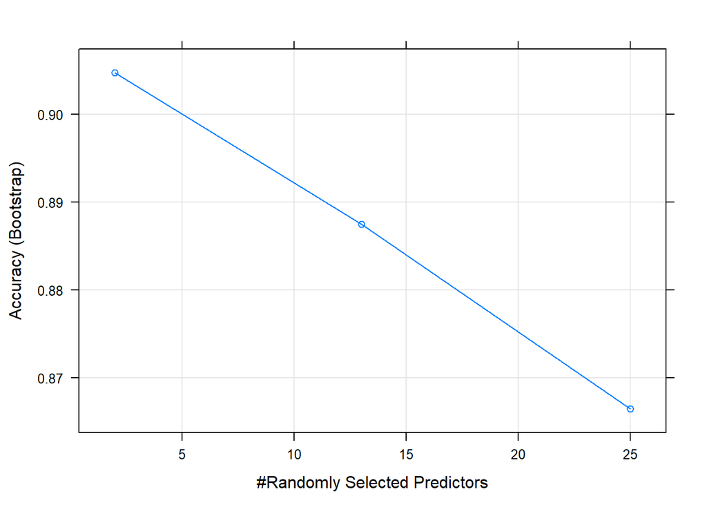

### 5.1.1 Random Forest - Metrika važnosti varijabli nebalansiranog skupa

Za bolji prikaz i interpretaciju podataka koristimo metriku važnosti značajka, te je dobivamo uvid u 20 varijabli koje su poredane silazno u odnosu na pridodani značaj. Prva po redu je zs odnosno otpor električne struje breskve, nakon nje theta odnosno imaginarni dio otpora breskve i volumen. Na prvi pogled se pregled važnosti čini realan, a podaci zadovoljavajući.

```r
varImp(model_rf_u, normalize = TRUE)
```

```
## rf variable importance
##
##   only 20 most important variables shown (out of 25)
##
##         Overall
## zs       100.00
## theta     83.40
## volume    77.89
## TA        69.64
## C1        63.49
## L1        61.18
## A1        59.25
## color     55.84
## B1        43.97
## C2        41.99
## WI_CIE1   41.94
## L2        41.03
## TSS       37.68
## WI_CIE2   36.16
## H1        35.81
## B2        35.67
## H2        35.60
## num       31.49
## dE2000    30.16
## A2        28.62
```

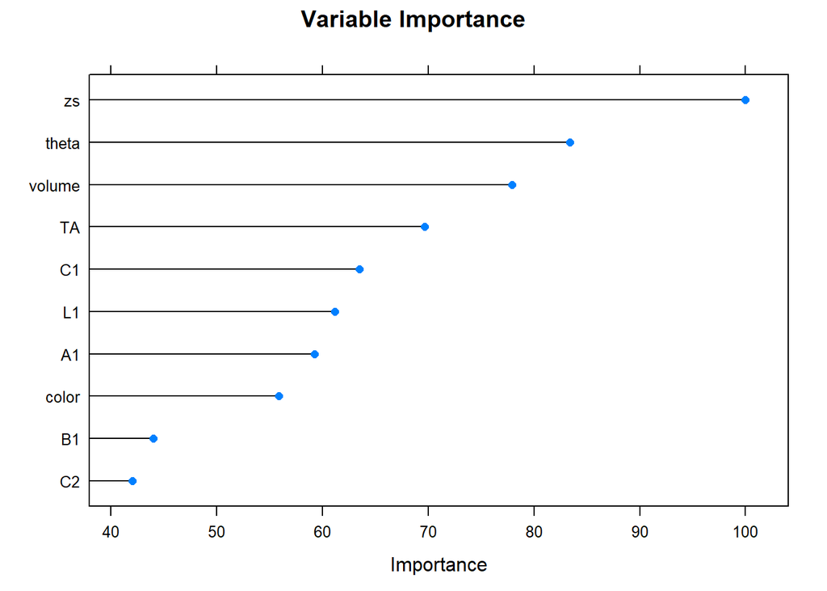

```r
varimpGraph_rf_u = varImp(model_rf_u, varImp.train = FALSE)
plot(varimpGraph_rf_u, top=10, main="Variable Importance")
```

### 5.1.2 Random Forest - Matrica konfuzije nebalansiranog skupa podataka

Matrica konfuzije u nastavku predviđa točnost od 90% što je i očekivano s obzirom na činjenicu da se radi o većinski nezrelom voću. Zbog velikog nebalansa skupova, ukoliko svaku jedinku voća klasificiramo kao nezrelu točnost će uvijek biti blizu 90%. Problem koji će se u svakom slučaju javiti je da zrelo voće neće biti moguće izolirati, kao u ovom slučaju gdje su sve tri jedinke zrelog voća klasificirane kao nezrele. Kao rješenje problema biti će uvedena metoda za generiranje sintetiziranih vrijednosti većinskog i manjinskog skupa skupova radi efikasnijeg treniranja modela nad više podataka.

```r
 test_predict = predict(model_rf_u, data_test)
 confusionMatrix(test_predict,as.factor(data_test$target))
```

```
## Confusion Matrix and Statistics
##
##           Reference
## Prediction  0  1
##          0 27  3
##          1  0  0
##
##                Accuracy : 0.9
##                  95% CI : (0.7347, 0.9789)
##     No Information Rate : 0.9
##     P-Value [Acc > NIR] : 0.6474
##
##                   Kappa : 0
##
##  Mcnemar's Test P-Value : 0.2482
##
##             Sensitivity : 1.0
##             Specificity : 0.0
##          Pos Pred Value : 0.9
##          Neg Pred Value : NaN
##              Prevalence : 0.9
##          Detection Rate : 0.9
##    Detection Prevalence : 1.0
##       Balanced Accuracy : 0.5
##
##        'Positive' Class : 0
##
```

# 6 Balansiranje skupova podataka metodom SMOTE

Metoda za balansiranje modela SMOTE je sastavni dio DMwR paketa koji je potrebno učitati.

```r
#install.packages('DMwR')
library(DMwR)
```

U nastavku stvaramo varijablu koja sadrži skup za treniranje obrađen SMOTE funkcijom za balansiranje. Pritom je čvrstoća kao varijabla balansiranja ignorirana zbog visoke korelacije s ciljnom varijablom. Za shvaćanje rada ovog algoritma nužno je objasniti rad parametara:

- *perc_over* - Generira sintetizirane vrijednosti manjinskog skupa (Zrelih jedinki voća)
- *perc_under* - Generira sintetizirane vrijednosti većinskog skupa (Nezrelih jedinki voća)

Radi daljnje obrade u kojoj podaci trebaju biti balansirani poželjno je da omjer većinskog i manjinskog skupa bude 50:50, što je predloženim vrijednostima uspješno postignuto. Vrijednosti su odabrane kroz brojne pokušaje provođenja modela u nastavku u odnosu na rezultate koji su generirali. Posebno je bilo potrebno uzeti u obzir fenomen loše varijance između podataka i potenciranje loših svojstava kod prevelikog broja sintetiziranih vrijednosti.

```r
train_balanced = SMOTE (target ~ .-firm,
                        data = data_train,
                        perc.over = 250,
                        perc.under=150
                        )

prop.table(table(train_balanced$target))
```

```
##
##   0   1
## 0.5 0.5
```

# 7 Primjena balansiranih algoritama

U nastavku slijedi primjena balansiranog skupa podataka u algoritmima slučajnih šuma i logističke regresije.

## 7.1 Random Forest algoritam - Balansirani skup podataka

```r
set.seed(42)

model_rf_bal = train(target ~ .-firm,
                 data = train_balanced,
                 method = "rf",
                 preProcess = c("scale", "center"),
                 trControl = fit_control,
                 verbose = FALSE)

model_rf_bal
```

```
## Random Forest
##
## 42 samples
## 23 predictors
##  2 classes: '0', '1'
##
## Pre-processing: scaled (25), centered (25)
## Resampling: Cross-Validated (10 fold, repeated 3 times)
## Summary of sample sizes: 38, 38, 38, 38, 38, 38, ...
## Resampling results across tuning parameters:
##
##   mtry  Accuracy   Kappa
##    2    0.9066667  0.8111111
##   13    0.9216667  0.8404040
##   25    0.9000000  0.7934343
##
## Accuracy was used to select the optimal model using the largest value.
## The final value used for the model was mtry = 13.
```

U nastavku slijedi grafički prikaz točnosti modela slučajnih šuma balansiranog skupa sa svim prediktorima.

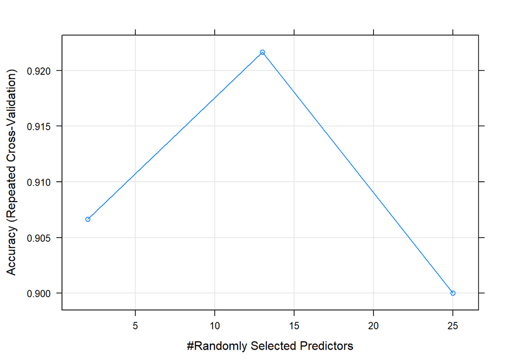

### 7.1.1 Random Forest - Metrika važnosti varijabli balansiranog skupa

U odnosu na nebalansirani skup podataka vidljivo je kako su se važnosti drastično promijenile. Trenutno su kao najvažnije varijable prezentirane redom: volume, color, C2, L1, *itd*…

```r
varImp(model_rf_bal, normalize = TRUE)
```

```
## rf variable importance
##
##   only 20 most important variables shown (out of 25)
##
##         Overall
## volume  100.000
## color    48.505
## C2       36.451
## L1       22.350
## zs       21.925
## L2       20.465
## mass     13.343
## num      11.461
## dE2000    8.824
## theta     5.392
## B1        5.119
## A1        4.993
## TSS       4.257
## B2        3.924
## TA        3.221
## H1        2.755
## C1        2.684
## A2        2.590
## WI_CIE1   2.432
## WI_CIE2   1.605
```

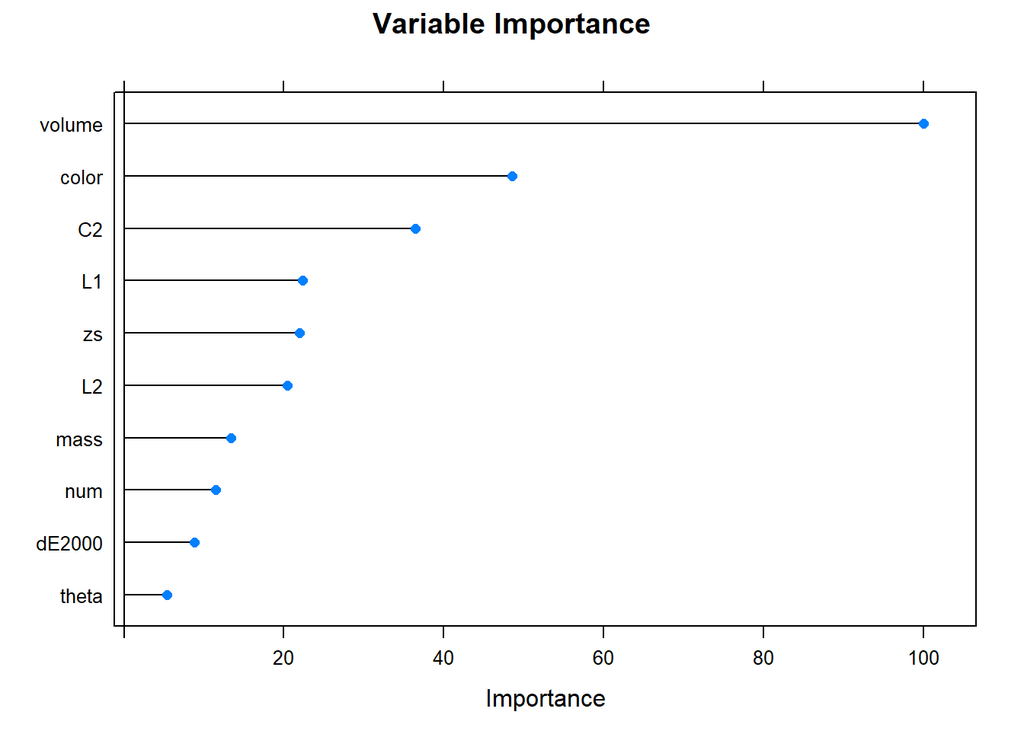

```r
varimpGraph_rf_bal = varImp(model_rf_bal, varImp.train = FALSE)
plot(varimpGraph_rf_bal, top=10, main="Variable Importance")
```

### 7.1.2 Random Forest - Matrica konfuzije balansiranog skupa podataka

```r
test_predict = predict(model_rf_bal, data_test)
confusionMatrix(test_predict,as.factor(data_test$target))
```

```
## Confusion Matrix and Statistics
##
##           Reference
## Prediction  0  1
##          0 25  0
##          1  2  3
##
##                Accuracy : 0.9333
##                  95% CI : (0.7793, 0.9918)
##     No Information Rate : 0.9
##     P-Value [Acc > NIR] : 0.4114
##
##                   Kappa : 0.7143
##
##  Mcnemar's Test P-Value : 0.4795
##
##             Sensitivity : 0.9259
##             Specificity : 1.0000
##          Pos Pred Value : 1.0000
##          Neg Pred Value : 0.6000
##              Prevalence : 0.9000
##          Detection Rate : 0.8333
##    Detection Prevalence : 0.8333
##       Balanced Accuracy : 0.9630
##
##        'Positive' Class : 0
##
```

U modelu logističke regresije pretpostavljeni ishodi odnosno rezultati modeliraju se kao linearna kombinacija varijabli predviđanja.

```r
#summary(train_balanced$color)

data_log <- train_balanced %>%
  mutate(color = as.factor(ifelse(color<52,"Lighter","Darker")))

set.seed(42)

model_lm <- lm(firm ~ color-target, data = data_log, )
summary(model_lm)
```

```
##
## Call:
## lm(formula = firm ~ color - target, data = data_log)
##
## Residuals:
##      Min       1Q   Median       3Q      Max
## -1.20816 -0.46737 -0.16118  0.02803  1.97303
##
## Coefficients:
##              Estimate Std. Error t value Pr(>|t|)
## (Intercept)    0.6070     0.1945   3.121 0.003339 **
## colorLighter   1.0729     0.2818   3.807 0.000473 ***
## ---
## Signif. codes:  0 '***' 0.001 '**' 0.01 '*' 0.05 '.' 0.1 ' ' 1
##
## Residual standard error: 0.9121 on 40 degrees of freedom
## Multiple R-squared:  0.266,  Adjusted R-squared:  0.2476
## F-statistic: 14.49 on 1 and 40 DF,  p-value: 0.000473
```

0.6070 + 1.0729 · color.Lighter

Za drugi primjer napraviti ćemo model koji koristi sve varijable kako bi predvidio zrelost breskve.

```r
set.seed(42)

model_lm <- lm(firm ~ .-target, data = train_balanced)
summary(model_lm)
```

```
##
## Call:
## lm(formula = firm ~ . - target, data = train_balanced)
##
## Residuals:
##      Min       1Q   Median       3Q      Max
## -0.41826 -0.08138 -0.00184  0.07336  0.35752
##
## Coefficients:
##               Estimate Std. Error t value Pr(>|t|)
## (Intercept)  4.313e+02  6.144e+01   7.019 2.06e-06 ***
## num         -7.464e-03  2.920e-03  -2.557 0.020428 *
## volume       6.275e-02  2.552e-02   2.459 0.024955 *
## mass        -1.602e-01  4.187e-02  -3.826 0.001354 **
## TSS          3.946e-01  1.675e-01   2.356 0.030757 *
## TA          -4.469e+00  1.310e+00  -3.411 0.003329 **
## zs          -3.745e+00  2.192e+00  -1.709 0.105678
## theta       -2.585e-01  7.302e-02  -3.539 0.002519 **
## AE4         -2.419e+00  4.883e-01  -4.954 0.000121 ***
## AE5         -2.414e+00  6.336e-01  -3.810 0.001400 **
## AE6         -2.664e+00  6.019e-01  -4.427 0.000370 ***
## color       -4.583e+00  6.446e-01  -7.110 1.75e-06 ***
## dE2000      -1.847e+00  5.079e-01  -3.638 0.002036 **
## L1          -4.080e+00  6.329e-01  -6.447 6.03e-06 ***
## A1          -6.165e-01  3.089e-01  -1.996 0.062237 .
## B1          -3.097e-01  3.052e-01  -1.015 0.324324
## C1           1.060e+00  3.761e-01   2.818 0.011846 *
## H1           6.696e-03  1.722e-03   3.889 0.001180 **
## WI_CIE1      7.844e-04  2.092e-04   3.750 0.001596 **
## L2          -4.470e+00  7.792e-01  -5.737 2.42e-05 ***
## A2           1.604e+00  4.448e-01   3.606 0.002182 **
## B2           1.205e+00  4.216e-01   2.859 0.010867 *
## C2           4.326e+00  6.466e-01   6.690 3.80e-06 ***
## H2           3.081e+00  4.998e-01   6.165 1.04e-05 ***
## WI_CIE2      1.093e-02  1.489e-03   7.341 1.15e-06 ***
## ---
## Signif. codes:  0 '***' 0.001 '**' 0.01 '*' 0.05 '.' 0.1 ' ' 1
##
## Residual standard error: 0.2358 on 17 degrees of freedom
## Multiple R-squared:  0.9792, Adjusted R-squared:  0.9497
## F-statistic: 33.27 on 24 and 17 DF,  p-value: 4.756e-10
```

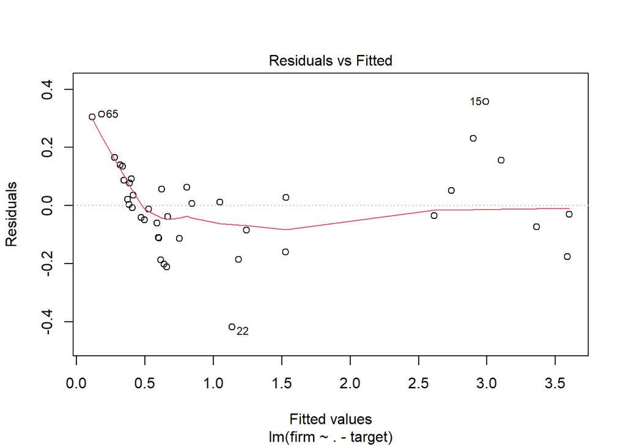

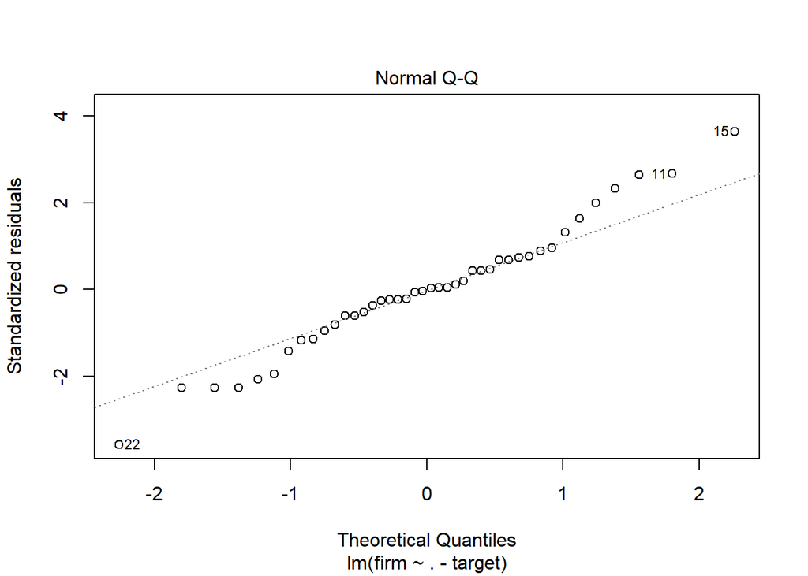

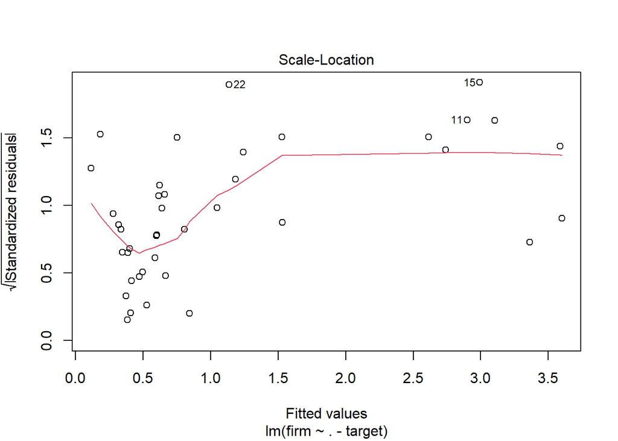

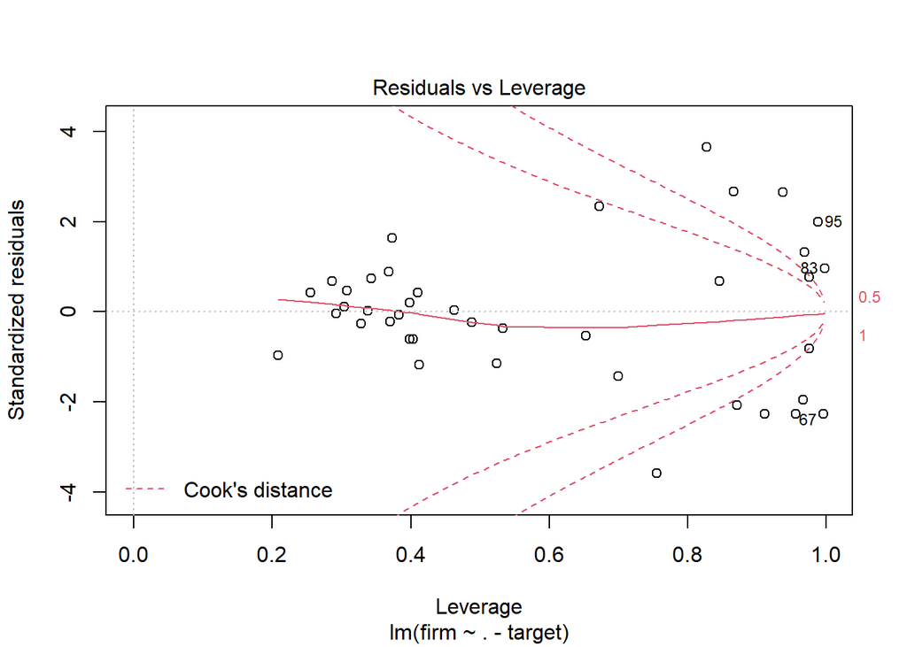

## 7.3 Implementacija metrike važnosti iz paketa Dalex

Za dodatno objašnjenje modela nad balansiranim podacima korištena je metrika važnosti paketa Dalex te je biblioteku potrebno učitati. Cilj je otkriti postoji li neka treća perspektiva o važnosti varijabli permutiranjem svakog pojedinog stupca.

### 7.3.1 Metrika važnosti nad balansiranim modelom slučajnih šuma

```r
#install.packages("DALEX")
library("DALEX")
```

Za početak je početno napraviti jedinistvenu reprezentaciju balansiranog modela funkcijom *explain()* gdje se definira ciljna varijabla. Nadalje je potrebno pridružiti skup podataka za testiranje nad kojim će se provjera provoditi.

U nastavku također slijedi ispis podataka o modelu.

```r
explain_rf_bal <- explain(model_rf_bal,
                   data = data_test,
                   y = data_test$target,
                 label = "Balanced dataset")
```

```
## Preparation of a new explainer is initiated
##   -> model label       :  Balanced dataset
##   -> data              :  30  rows  24  cols
##   -> target variable   :  30  values
##   -> predict function  :  yhat.train  will be used (  default  )
##   -> predicted values  :  numerical, min =  0.002 , mean =  0.2558 , max =  0.9
##   -> model_info        :  package caret , ver. 6.0.86 , task classification (  default  )
##   -> model_info        :  Model info detected classification task but 'y' is a factor .  (  WARNING  )
##   -> model_info        :  By deafult classification tasks supports only numercical 'y' parameter.
##   -> model_info        :  Consider changing to numerical vector with 0 and 1 values.
##   -> model_info        :  Otherwise I will not be able to calculate residuals or loss function.
##   -> residual function :  difference between y and yhat (  default  )
##   -> residuals         :  numerical, min =  NA , mean =  NA , max =  NA
##   A new explainer has been created!
```

Nakon što je model objašnjen, metodom *model_parts()* permutiramo svaku pojedinu varijablu respektivo. Provodi se 50 permutacija nad cijelim skupom podataka te ukoliko je varijabla koja se permutira važna, vrijednost *mean_droput_loss* će biti veća.

Problem ove metode je nasumična priroda permutacija zbog koje rezultati nikada neće biti jednoznačni. Zbog toga je potrebno analizu provesti više puta i na taj način formirati subjektivno opažanje. Permutacija je skupa operacija po pitanju rersursa te obrada većih skupova podataka može biti dugotrajan proces, što u ovoj analizi nije bio slučaj.

```r
set.seed(42)

vimp_rf_bal <- model_parts (explain_rf_bal, B = 50, N = NULL)
vimp_rf_bal
```

```
##        variable mean_dropout_loss            label
## 1  _full_model_       0.024691358 Balanced dataset
## 2            L2       0.004444444 Balanced dataset
## 3          mass       0.015802469 Balanced dataset
## 4        dE2000       0.022962963 Balanced dataset
## 5          firm       0.024691358 Balanced dataset
## 6            TA       0.024691358 Balanced dataset
## 7            AE       0.024691358 Balanced dataset
## 8            B1       0.024691358 Balanced dataset
## 9            C1       0.024691358 Balanced dataset
## 10      WI_CIE1       0.024691358 Balanced dataset
## 11           H2       0.024691358 Balanced dataset
## 12      WI_CIE2       0.024691358 Balanced dataset
## 13       target       0.024691358 Balanced dataset
## 14        theta       0.024691358 Balanced dataset
## 15           zs       0.024938272 Balanced dataset
## 16           B2       0.025185185 Balanced dataset
## 17          num       0.025185185 Balanced dataset
## 18           A2       0.025432099 Balanced dataset
## 19           H1       0.026172840 Balanced dataset
## 20           L1       0.027654321 Balanced dataset
## 21        color       0.031851852 Balanced dataset
## 22          TSS       0.035061728 Balanced dataset
## 23           A1       0.036049383 Balanced dataset
## 24           C2       0.106419753 Balanced dataset
## 25       volume       0.244691358 Balanced dataset
## 26   _baseline_       0.485185185 Balanced dataset
```

### 7.3.2 Vizualizacija metode važnosti varijable

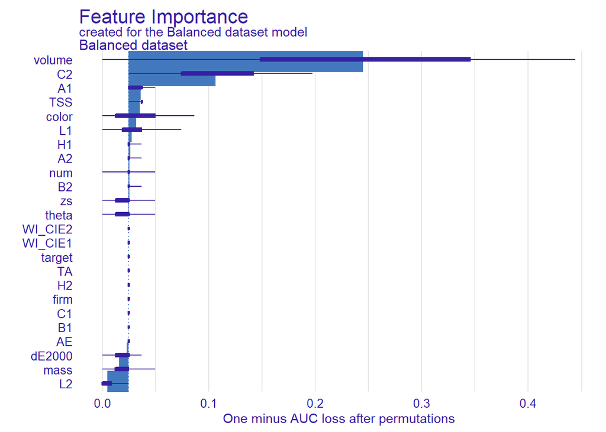

## 7.4 Random Forest algoritam 2 - Balansirani skup podataka

Za testiranje prije dobivenih pretpostavki izabrane su varijable koje su prethodni modeli izabrali kao najvažnije. Iz tog skupa varijabli su izbačene prije objašnjene invazivne metode otkrivanja zrelosti, a ostavljene su one koje se odnose na fizičko svojstvo volumena i obojenosti svake jedinke voća.

Te varijable su:

- volume - Model slučajne šume i metrika važnosti varijable su ga označili kao najbitnijeg
- WI_CIE2 - Pretpostavljen kao prva najvažnija varijabla od strane logističke regresije
- color - Pretpostavljen kao druga najvažnija varijabla od strane logističke regresije i modela slučajnih šuma
- C2 - Pretpostavljen kao druga najvažnija varijabla od strane metrike važnosti
- L2 - Ima najveću negativnu razliku u metrici važnosti
- L1 - Pretpostavljen kao važan od strane logističke regresije

```r
set.seed(42)

model_rf_bal_2 = train(target ~ volume + color + L1 + L2 + C2  + WI_CIE2,
                 data = train_balanced,
                 method = "rf",
                 preProcess = c("scale", "center"),
                 trControl = fit_control,
                 verbose = FALSE)

model_rf_bal_2
```

```
## Random Forest
##
## 42 samples
##  6 predictor
##  2 classes: '0', '1'
##
## Pre-processing: scaled (6), centered (6)
## Resampling: Cross-Validated (10 fold, repeated 3 times)
## Summary of sample sizes: 38, 38, 38, 38, 38, 38, ...
## Resampling results across tuning parameters:
##
##   mtry  Accuracy   Kappa
##   2     0.9216667  0.8448718
##   4     0.8916667  0.7767677
##   6     0.8816667  0.7560606
##
## Accuracy was used to select the optimal model using the largest value.
## The final value used for the model was mtry = 2.
```

Izgrađeni model nad skupom za treniranje ima točnost od 92.16% u drugom pokušaju.

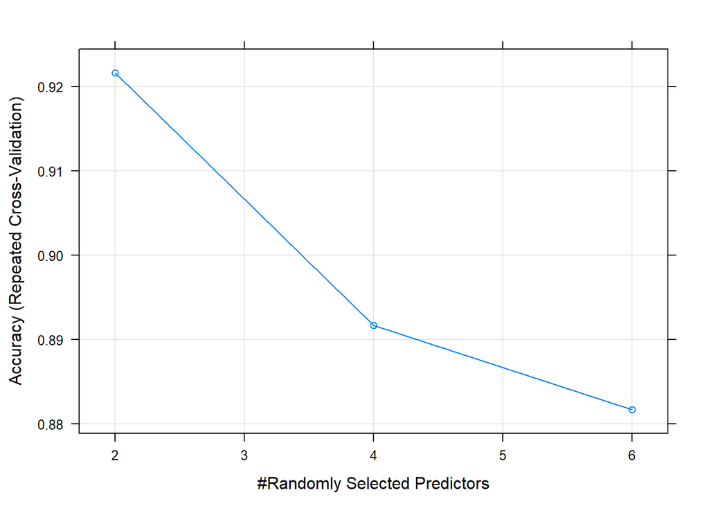

```r
varImp(model_rf_bal_2, normalize = TRUE)
```

```
## rf variable importance
##
##         Overall
## volume   100.00
## C2        51.80
## color     49.41
## L2        38.95
## L1        31.83
## WI_CIE2    0.00
```

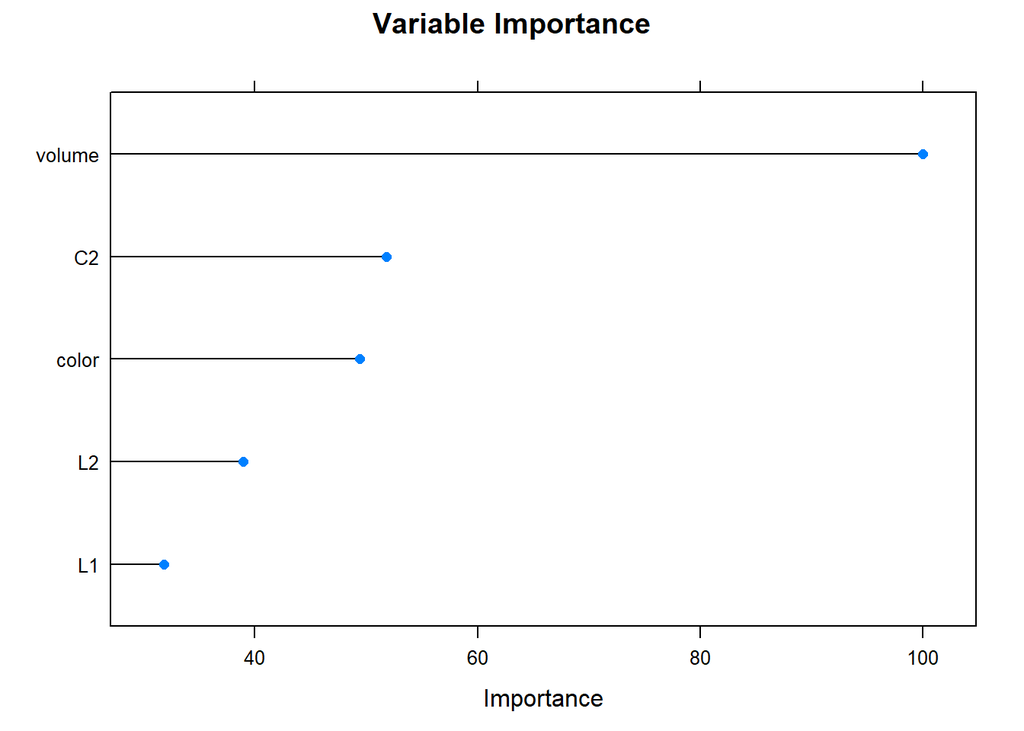

```r
varimpGraph_rf_bal_2 = varImp(model_rf_bal_2, varImp.train = FALSE)
plot(varimpGraph_rf_bal_2, top=5, main="Variable Importance")
```

```r
test_predict = predict(model_rf_bal_2, data_test)
confusionMatrix(test_predict,as.factor(data_test$target))
```

```
## Confusion Matrix and Statistics
##
##           Reference
## Prediction  0  1
##          0 24  0
##          1  3  3
##
##                Accuracy : 0.9
##                  95% CI : (0.7347, 0.9789)
##     No Information Rate : 0.9
##     P-Value [Acc > NIR] : 0.6474
##
##                   Kappa : 0.6154
##
##  Mcnemar's Test P-Value : 0.2482
##
##             Sensitivity : 0.8889
##             Specificity : 1.0000
##          Pos Pred Value : 1.0000
##          Neg Pred Value : 0.5000
##              Prevalence : 0.9000
##          Detection Rate : 0.8000
##    Detection Prevalence : 0.8000
##       Balanced Accuracy : 0.9444
##
##        'Positive' Class : 0
##
```

# 8 Zaključak

Cilj ovog projekta bio je uz pomoć programske podrške riješiti nebalansirani problem na praktičnom primjeru – predvidjeti zrelost voća ovisno o važnosti parametara.

U radu je prikazana priprema podataka te balansiranje SMOTE algoritmom. Nad balansiranim podacima je izvršeno predviđanje zrelosti algoritmima Random forest, logističkom regresijom i matricom konfuzije te je i dodatno pojašnjena važnost varijabli uz pomoć paketa DALEX korištenjem permutacija i korištenjem metrike važnosti varijabli. Za potrebe usporedbe, prije balansiranja podataka izvršeno je predviđanje zrelosti algoritmima Random forest i matricom konfuzije te objašnjenje varijabli korištenjem metrike važnosti varijabli.

Kako bi još bolje predvidjeli zrelost voća iz skupa varijabli izbačene su invazivne metode otkrivanja zrelosti kao što su stiskanje voća radi provjere tvrdoće ili provođenje struje (npr. theta i zs), a ostavljane su one koje se odnose na fizičko svojstvo volumena i obojenosti svake jedinke voća. Samim time došli smo do najvažnijih parametara u određivanju zrelosti voća, a to su redom:

- Volume – volumen breskve u cm3
- C2 – CIELCh komponente najsvjetlijeg dijela breskve
- Color – svjetlina breskve (pretpostavka)
- L2 – CIELAB komponente najsvjetlijeg dijela breskve
- L1 – CIELAB komponente najtamnijeg dijela breskve
- WI_CIE2 - CIE Whiteness Index najsvjetlijeg dijela breskve

# 9 Literatura

- https://rikunert.com/SMOTE_explained
- https://builtin.com/data-science/random-forest-algorithm
- https://medium.com/@sonish.sivarajkumar/logistic-regression-for-beginners-4881ae431870
- http://ema.drwhy.ai/featureImportance.html
- https://stats.stackexchange.com/questions/183320/logistic-glm-with-good-predictors-is-giving-p-values-1?fbclid=IwAR0Sjyzr-evE3d3yCjJASK9SgunWjHxsde4C86ZwCnsAg0ukh1a-jFuKLQI